### Pre-defined graphical plots

#### Static plots

The call of the `plot()` function with a `PrepGR` object draws the observed precipitation and discharge time series.

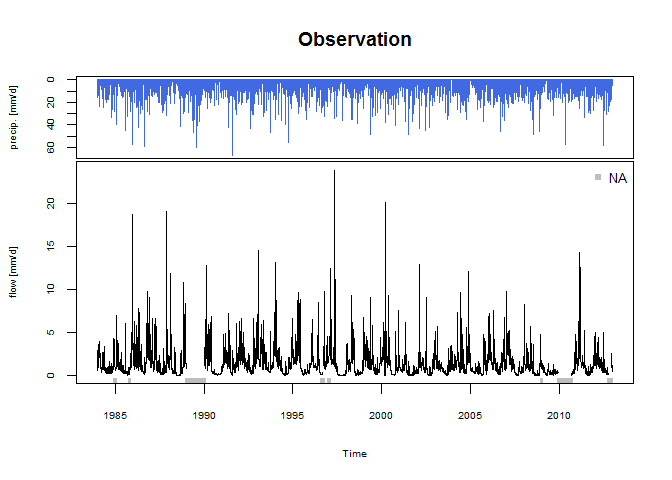

```r
plot(PREP, main = "Observation")
```

By default (with the argument `which = "perf"`), the call of the `plot()` function with a `CalGR` object draws the classical **airGR** plot diagnostics (observed and simulated time series together with diagnostic plot)

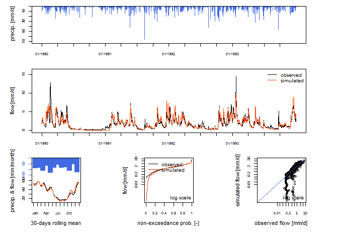

```r
plot(CAL, which = "perf")
```

With the `CalGR` object, if the argument `which` is set to `"iter"`, the `plot()` function draws the evolution of the parameters and the values of the objective function during the second step of the calibration (steepest descent local search algorithm):

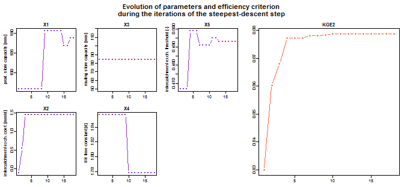

```r
plot(CAL, which = "iter")
```

With the `CalGR` object, if the argument `which` is set to `"ts"`, the `plot()` function simply draws the time series of the observed precipitation, and the observed and simulated flows:

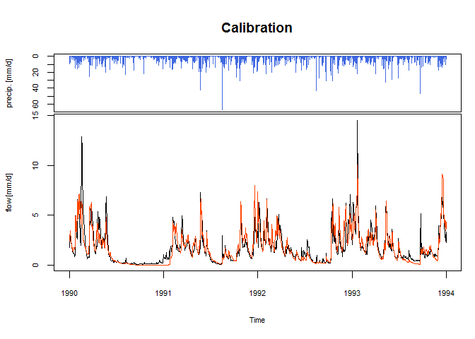

```r
plot(CAL, which = "ts", main = "Calibration")
```

The call of the `plot()` function with a `SimGR` object draws the classical **airGR** plot diagnostics.

```r
plot(SIM)
```

[output not shown]

#### Dynamic plots

Dynamic plots, using the *dygraphs* JavaScript charting library, can be displayed by the package.

The `dyplot()` function can be applied on `PrepGR`, `CalGR` and `SimGR` objects and draws the time series of the observed precipitation, and the observed and simulated (except with `PrepGR` objects) flows.

The user can zoom on the plot device and can read the exact values.

With this function, users can easily explore the data time series and also explore and interpret the possible problems of the calibration or simulation steps.

```r
dyplot(SIM, main = "Simulation")
```

### Graphical user interface

The **airGRteaching** package also provides the `ShinyGR()` function, which allows to launch a graphical user interface using the *shiny* package.

The `ShinyGR()` function needs at least:

- `ObsDF`: a (list of) `data.frame` (or independant vector instead, see `?ShinyGR`)
- `SimPer`: a (list of) vector(s) of 2 dates to define the simulation period(s)

```r
ShinyGR(ObsDF = BasinObs, SimPer = c("1994-01-01", "1998-12-31"))
```

Only monthly and daily models are currently available (GR2M, GR4J, GR5J, GR6J + CemaNeige).

If you want to use CemaNeige, you also have to define the same arguments desribed above for the `PrepGR()` function.

It is also possible to change the interface look; different themes are proposed (`theme` argument).